# 🇳🇱 Step 6: Dutch Market Specialized MMM Model

## 📋 **Project Context**

This is our **final and most sophisticated MMM model** that incorporates deep Dutch market knowledge. We add 15+ Netherlands-specific features to create a model that truly understands local business patterns and cultural behaviors.

## 🎯 **Business Objective**

Create a market-specific MMM that:

- Captures unique Dutch cultural and seasonal patterns
- Incorporates Netherlands holidays and school calendars
- Understands local weather impact patterns
- Provides culturally-informed strategic recommendations
- Achieves best-in-class performance for Dutch ice cream market

## 🔄 **Dutch Market Specialization**

### **2. Dutch School Calendar Effects**

- **Summer Holidays** (July-August): Peak ice cream season with families
- **May Break** (Week around May 1): Spring vacation boost
- **Autumn Break** (October): Season extension opportunity
- **Winter Break**: Minimal ice cream consumption
- **Weekend Effects**: Dutch weekend culture impact

### **3. Dutch Weather Intelligence**

- **Heat Wave Definition**: Netherlands-specific temperature thresholds
- **Indian Summer**: Late season warm weather (key business opportunity)
- **Dutch Spring Pattern**: Gradual temperature rise vs. sudden spikes
- **Rainy Season Impact**: Netherlands rainfall patterns vs. ice cream sales
- **Seasonal Transitions**: How Dutch weather patterns affect marketing timing

### **4. Dutch Cultural Business Patterns**

- **Outdoor Season Intensity**: Netherlands outdoor culture calendar
- **Holiday Shopping Patterns**: How holidays affect ice cream as impulse purchase
- **Weekend vs. Weekday**: Dutch work-life balance impact on consumption
- **Payday Effects**: Monthly salary cycles in Netherlands
- **Tourism Season**: International visitors impact during peak season

## 🎯 **Advanced MMM Features for Netherlands**

### **Dutch Seasonality Intelligence**

- **Natural Season Intensity**: How strongly each season affects ice cream
- **Holiday Interaction Effects**: How holidays amplify weather impact
- **Cultural Event Calendar**: Local events that drive consumption
- **School vs. Work Pattern**: Different consumer segments, different patterns

### **Netherlands Weather Sophistication**

- **Temperature Thresholds**: Dutch consumer behavior at different temperatures
- **Weather Trend Recognition**: Improving vs. declining weather periods
- **Seasonal Weather Expectations**: How current weather compares to normal
- **Weather Marketing Triggers**: When weather justifies increased spending

### **Dutch Marketing Calendar Optimization**

- **Pre-Holiday Activation**: Building awareness before major holidays
- **Season Extension Strategy**: Maximizing shoulder seasons
- **Weather-Responsive Planning**: Dynamic spending based on forecasts
- **Cultural Moment Leverage**: Capitalizing on uniquely Dutch occasions

## 🔧 **Model Architecture Enhancements**

### **2. Local Business Logic Integration**

- **Ice Cream Season Definition**: Dutch-specific season start/end dates
- **Weather Response Curves**: How Dutch consumers respond to temperature
- **Holiday Spending Patterns**: Marketing effectiveness during holidays
- **Seasonal Marketing Efficiency**: When channels work best in Netherlands

### **3. Advanced Model Calibration**

- **Local Benchmark Validation**: Compare to Netherlands ice cream industry norms
- **Cultural Sense Checking**: Do insights align with Dutch market expertise?
- **Regional Weather Validation**: Model captures known weather-sales relationships
- **Holiday Effect Validation**: Holiday impacts match business experience

## 📊 **Target Performance**

### **Business Value Delivered:**

- **Dutch Holiday Strategy**: How to leverage Netherlands cultural calendar
- **Weather-Responsive Planning**: Dynamic media strategies based on Dutch weather
- **Seasonal Optimization**: Netherlands-specific season extension opportunities
- **Cultural Marketing**: Leverage unique Dutch consumption patterns

## 🎯 **Netherlands Business Insights**

### **Strategic Recommendations:**

- **Q1 Strategy**: Brand building during low season
- **Q2 Strategy**: Holiday activation (King's Day, Liberation Day, May Break)
- **Q3 Strategy**: Peak summer maximization with tourism boost
- **Q4 Strategy**: Season extension through Indian Summer and weather triggers

## 🔧 **Technical Implementation**

```python
# 🇳🇱 06 DUTCH SEASONALITY MODEL - COMPREHENSIVE ANALYSIS
# ========================================================
#
# OBJECTIVE: Enhance 05 baseline with Netherlands-specific seasonality features
# WHY: Ice cream is highly seasonal and culture-dependent in Netherlands
# APPROACH: Add Dutch holidays, weather patterns, and cultural effects
# RESULT: 51.2% → 52.6% Test R² (+1.4% improvement with business relevance)

import pandas as pd
import numpy as np
import matplotlib.pyplot as plt
from sklearn.preprocessing import StandardScaler
from sklearn.feature_selection import SelectKBest, f_regression
from sklearn.linear_model import RidgeCV
from sklearn.model_selection import TimeSeriesSplit
from sklearn.metrics import r2_score
import warnings
warnings.filterwarnings('ignore')

print("🇳🇱 06 DUTCH SEASONALITY ENHANCEMENT - COMPREHENSIVE ANALYSIS")
print("=" * 65)
print("🎯 Goal: Make our MMM model relevant for Dutch ice cream market")
print("📊 Method: Add Netherlands-specific seasonal and cultural features")
```

```
🇳🇱 06 DUTCH SEASONALITY ENHANCEMENT - COMPREHENSIVE ANALYSIS
=================================================================
🎯 Goal: Make our MMM model relevant for Dutch ice cream market
📊 Method: Add Netherlands-specific seasonal and cultural features
```

```python
# 📊 WHY DUTCH SEASONALITY MATTERS
# ================================

print(f"\n📊 WHY DUTCH SEASONALITY IS CRITICAL FOR ICE CREAM")
print("=" * 55)
print("🎯 BUSINESS CONTEXT:")
print("   • Ice cream is highly seasonal and culture-dependent")
print("   • Dutch holidays drive outdoor activities → ice cream sales")
print("   • Netherlands climate: short summers, rare heat waves")
print("   • Dutch school calendar affects family consumption patterns")
print("   • Local cultural behaviors impact purchasing timing")
print()
print("❌ PREVIOUS PROBLEM:")
print("   • Model used generic seasonality features")
print("   • No Dutch holiday effects captured")
print("   • Missing Netherlands-specific weather patterns")
print("   • Stakeholders couldn't relate to model features")
print()
print("✅ OUR SOLUTION:")
print("   • Add King's Day, Liberation Day (major Dutch celebrations)")
print("   • Include Dutch school holiday periods")
print("   • Model Netherlands climate patterns (heat waves >25°C)")
print("   • Capture Dutch cultural consumption behaviors")
```

```
📊 WHY DUTCH SEASONALITY IS CRITICAL FOR ICE CREAM
=======================================================
🎯 BUSINESS CONTEXT:
   • Ice cream is highly seasonal and culture-dependent
   • Dutch holidays drive outdoor activities → ice cream sales
   • Netherlands climate: short summers, rare heat waves
   • Dutch school calendar affects family consumption patterns
   • Local cultural behaviors impact purchasing timing

❌ PREVIOUS PROBLEM:
   • Model used generic seasonality features
   • No Dutch holiday effects captured
   • Missing Netherlands-specific weather patterns
   • Stakeholders couldn't relate to model features

✅ OUR SOLUTION:
   • Add King's Day, Liberation Day (major Dutch celebrations)
   • Include Dutch school holiday periods
   • Model Netherlands climate patterns (heat waves >25°C)
   • Capture Dutch cultural consumption behaviors
```

```python
# 📊 DATA LOADING AND SETUP
# ==========================

# Load the same train/test datasets as 05 baseline for fair comparison
train_data = pd.read_csv('../data/mmm_ready/consistent_channels_train_set.csv')
test_data = pd.read_csv('../data/mmm_ready/consistent_channels_test_set.csv')

print(f"\n📊 DATASET VALIDATION")
print("=" * 25)
print(f"✅ Training: {len(train_data)} weeks (2022-2024)")
print(f"✅ Test: {len(test_data)} weeks (2024-2025)")
print(f"✅ Temporal split: Test data comes AFTER training (no data leakage)")
print(f"✅ Same data as 05 baseline (fair comparison)")

# Analyze existing features
baseline_features = [col for col in train_data.columns if col not in ['date', 'sales']]
media_features = [f for f in baseline_features if 'cost' in f or 'spend' in f]
control_features = [f for f in baseline_features if f not in media_features]

print(f"\n📋 BASELINE FEATURES AVAILABLE:")
print(f"   • Media channels: {len(media_features)} (search, TV, radio, social, OOH)")
print(f"   • Control variables: {len(control_features)} (weather, seasonality, promos)")
print(f"   • Total baseline features: {len(baseline_features)}")
```

```
📊 DATASET VALIDATION
=========================
✅ Training: 129 weeks (2022-2024)
✅ Test: 27 weeks (2024-2025)
✅ Temporal split: Test data comes AFTER training (no data leakage)
✅ Same data as 05 baseline (fair comparison)

📋 BASELINE FEATURES AVAILABLE:
   • Media channels: 7 (search, TV, radio, social, OOH)
   • Control variables: 8 (weather, seasonality, promos)
   • Total baseline features: 15
```

```python
# 🇳🇱 DUTCH SEASONALITY FEATURE ENGINEERING
# ===========================================

def create_dutch_seasonality_features(df):
    """
    Engineer Netherlands-specific seasonality features for ice cream business

    FEATURE CATEGORIES:
    1. 🎆 Dutch National Holidays - Major outdoor celebrations
    2. 🏫 Dutch School Holidays - Family consumption peaks
    3. 🌡️ Dutch Weather Patterns - Netherlands climate specifics
    4. 🧀 Dutch Cultural Effects - Local consumer behaviors
    5. 🔗 Interaction Effects - Temperature × Holiday synergies
    """
    df = df.copy()
    df['date'] = pd.to_datetime(df['date'])

    # 1. 🎆 DUTCH NATIONAL HOLIDAYS

    # King's Day (April 27, or 26 if Sunday) - Biggest outdoor party in Netherlands
    # Millions of people celebrate outdoors → massive ice cream opportunity
    df['kings_day'] = ((df['date'].dt.month == 4) &
                      (df['date'].dt.day.isin([26, 27]))).astype(int)

    # Liberation Day (May 5) - Freedom festivals, outdoor concerts
    # Celebrates end of WWII with outdoor events → ice cream consumption
    df['liberation_day'] = ((df['date'].dt.month == 5) &
                           (df['date'].dt.day == 5)).astype(int)

    # Ascension Day & Whit Monday - Long weekends for outdoor activities
    # Note: These vary by year, simplified implementation for now
    df['ascension_day'] = 0    # Could enhance with exact Easter calculations
    df['whit_monday'] = 0      # Could enhance with exact Easter calculations

    # 2. 🏫 DUTCH SCHOOL HOLIDAYS

    # Summer holidays (July-August) - Peak family vacation period
    # Schools closed → families out → ice cream sales peak
    df['dutch_summer_holidays'] = (df['date'].dt.month.isin([7, 8])).astype(int)

    # May break (Meivakantie) - Spring school holiday
    # Often combined with national holidays for longer outdoor periods
    df['dutch_may_break'] = ((df['date'].dt.month == 5) &
                            (df['date'].dt.day <= 15)).astype(int)

    # Autumn break (Herfstvakantie) - October school holiday
    # Last chance for outdoor family activities before winter
    df['dutch_autumn_break'] = ((df['date'].dt.month == 10) &
                               (df['date'].dt.day <= 15)).astype(int)

    # 3. 🌡️ DUTCH WEATHER PATTERNS

    # Heat waves (>25°C) - Extremely rare but MASSIVE ice cream drivers
    # Netherlands has mild climate, so hot days create extraordinary demand
    df['dutch_heatwave'] = (df['weather_temperature_mean'] > 25).astype(int)

    # Warm spring days (>18°C in March-May) - Unexpected ice cream boost
    # Dutch people rush outside after cold winter → surprise consumption
    df['warm_spring_nl'] = ((df['date'].dt.month.isin([3, 4, 5])) &
                           (df['weather_temperature_mean'] > 18)).astype(int)

    # Indian summer (>20°C in September-October) - Extended season
    # Unexpected warm autumn weather extends ice cream season
    df['indian_summer_nl'] = ((df['date'].dt.month.isin([9, 10])) &
                             (df['weather_temperature_mean'] > 20)).astype(int)

    # 4. 🧀 DUTCH CULTURAL EFFECTS

    # Weekend boost - Dutch people socialize more on weekends
    # Weekend social activities → higher ice cream consumption
    df['weekend_boost'] = df['date'].dt.dayofweek.isin([5, 6]).astype(int)

    # Dutch outdoor season - When Dutch people spend time outside
    # Combines temperature threshold with outdoor months
    df['dutch_outdoor_season'] = ((df['date'].dt.month.isin([5, 6, 7, 8, 9])) &
                                 (df['weather_temperature_mean'] > 15)).astype(int)

    # Payday effects (1st and 15th) - Common payment dates in Netherlands
    # Disposable income peaks → discretionary spending like ice cream
    df['payday_effect'] = df['date'].dt.day.isin([1, 15]).astype(int)

    # 5. 🔗 INTERACTION EFFECTS

    # Temperature × Holiday interaction - Warm weather during celebrations
    # Hot weather during Dutch holidays = perfect storm for ice cream sales
    df['temp_holiday_interaction'] = (df['weather_temperature_mean'] *
                                     (df['kings_day'] + df['liberation_day'] +
                                      df['dutch_summer_holidays']))

    # Dutch ice cream season intensity curve
    # Models the intensity of ice cream season accounting for short Dutch summers
    month_day = df['date'].dt.month + df['date'].dt.day / 31
    df['dutch_ice_cream_season'] = np.where(
        (month_day >= 4) & (month_day <= 9),  # April to September
        np.sin((month_day - 4) * np.pi / 5) * (df['weather_temperature_mean'] / 20),
        0
    )

    return df

print(f"\n🇳🇱 DUTCH FEATURE ENGINEERING PROCESS")
print("=" * 42)
print("   🔄 Engineering Netherlands-specific features...")
print("   🎆 Adding Dutch national holidays (King's Day, Liberation Day)")
print("   🏫 Including Dutch school holiday periods")
print("   🌡️ Modeling Netherlands weather patterns (heat waves, warm spring)")
print("   🧀 Capturing Dutch cultural behaviors (weekend boost, outdoor season)")
print("   🔗 Creating temperature-holiday interaction effects")

# Apply feature engineering to both datasets
train_enhanced = create_dutch_seasonality_features(train_data)
test_enhanced = create_dutch_seasonality_features(test_data)

# Identify new Dutch features
dutch_features = [col for col in train_enhanced.columns if col not in train_data.columns]
print(f"✅ Successfully created {len(dutch_features)} Dutch seasonality features")

print(f"\n📋 NEW DUTCH FEATURES CREATED:")
for i, feature in enumerate(dutch_features, 1):
    # Categorize features for better understanding
    if 'day' in feature or 'liberation' in feature:
        category = "🎆 Holiday"
    elif 'holiday' in feature or 'break' in feature:
        category = "🏫 School"
    elif any(word in feature for word in ['heat', 'warm', 'summer', 'temp']):
        category = "🌡️ Weather"
    elif any(word in feature for word in ['weekend', 'outdoor', 'payday']):
        category = "🧀 Cultural"
    elif any(word in feature for word in ['interaction', 'season']):
        category = "🔗 Interaction"
    else:
        category = "📊 Other"

    print(f"   {i:2d}. {feature:<30} {category}")
```

```
🇳🇱 DUTCH FEATURE ENGINEERING PROCESS
==========================================
   🔄 Engineering Netherlands-specific features...
   🎆 Adding Dutch national holidays (King's Day, Liberation Day)
   🏫 Including Dutch school holiday periods
   🌡️ Modeling Netherlands weather patterns (heat waves, warm spring)
   🧀 Capturing Dutch cultural behaviors (weekend boost, outdoor season)
   🔗 Creating temperature-holiday interaction effects
✅ Successfully created 15 Dutch seasonality features

📋 NEW DUTCH FEATURES CREATED:
    1. kings_day                      🎆 Holiday
    2. liberation_day                 🎆 Holiday
    3. ascension_day                  🎆 Holiday
    4. whit_monday                    🎆 Holiday
    5. dutch_summer_holidays          🎆 Holiday
    6. dutch_may_break                🏫 School
    7. dutch_autumn_break             🏫 School
    8. dutch_heatwave                 🌡️ Weather
    9. warm_spring_nl                 🌡️ Weather
   10. indian_summer_nl               🌡️ Weather
   11. weekend_boost                  🧀 Cultural
   12. dutch_outdoor_season           🧀 Cultural
   13. payday_effect                  🎆 Holiday
   14. temp_holiday_interaction       🎆 Holiday
   15. dutch_ice_cream_season         🔗 Interaction
```

```python
# 🏗️ MODEL TRAINING FRAMEWORK
# ============================

def train_and_evaluate_model(train_df, test_df, model_name):
    """
    Train and evaluate model with proper MMM methodology

    VALIDATION PRINCIPLES:
    ✅ Pre-split train/test datasets (no data leakage)
    ✅ Feature selection to prevent overfitting (top 15)
    ✅ Ridge regression with cross-validation for stability
    ✅ TimeSeriesSplit for proper temporal validation
    ✅ Standardized features for fair comparison
    """

    # Prepare features (exclude date and target variable)
    feature_columns = [col for col in train_df.columns if col not in ['date', 'sales']]

    # Extract features and target, handle missing values
    X_train = train_df[feature_columns].fillna(0)
    y_train = train_df['sales']
    X_test = test_df[feature_columns].fillna(0)
    y_test = test_df['sales']

    # Standardize features (crucial for Ridge regression)
    scaler = StandardScaler()
    X_train_scaled = scaler.fit_transform(X_train)
    X_test_scaled = scaler.transform(X_test)

    # Feature selection: Keep top 15 features to prevent overfitting
    # This is critical for model generalization
    selector = SelectKBest(f_regression, k=min(15, X_train_scaled.shape[1]))
    X_train_selected = selector.fit_transform(X_train_scaled, y_train)
    X_test_selected = selector.transform(X_test_scaled)

    # Train Ridge regression with cross-validated alpha selection
    # TimeSeriesSplit respects temporal nature of data
    ridge = RidgeCV(alphas=np.logspace(-3, 3, 50), cv=TimeSeriesSplit(n_splits=5))
    ridge.fit(X_train_selected, y_train)

    # Generate predictions
    y_train_pred = ridge.predict(X_train_selected)
    y_test_pred = ridge.predict(X_test_selected)

    # Calculate performance metrics
    train_r2 = r2_score(y_train, y_train_pred)
    test_r2 = r2_score(y_test, y_test_pred)
    overfitting_gap = train_r2 - test_r2

    # Return comprehensive results
    return {
        'model_name': model_name,
        'train_r2': train_r2,
        'test_r2': test_r2,
        'overfitting_gap': overfitting_gap,
        'features_used': X_train_selected.shape[1],
        'y_test_actual': y_test,
        'y_test_predicted': y_test_pred,
        'model': ridge,
        'scaler': scaler,
        'selector': selector
    }
```

```python
# 🥊 MODEL COMPARISON: 05 BASELINE vs 06 DUTCH ENHANCED
# ======================================================

print(f"\n🥊 FAIR MODEL COMPARISON")
print("=" * 30)
print("Comparing 05 baseline vs 06 Dutch enhanced using identical methodology")
print("Only difference: 06 includes Dutch seasonality features")

# Train 05 Baseline Model
print(f"\n1️⃣ 05 BASELINE MODEL (Current Champion)")
print("-" * 45)
result_05 = train_and_evaluate_model(train_data, test_data, "05 Baseline")

print(f"📊 Performance Metrics:")
print(f"   • Features used: {result_05['features_used']}")
print(f"   • Train R²: {result_05['train_r2']:.3f}")
print(f"   • Test R²: {result_05['test_r2']:.3f}")
print(f"   • Overfitting gap: {result_05['overfitting_gap']:.3f}")

# Assess overfitting level
if result_05['overfitting_gap'] < 0.1:
    overfitting_05 = "✅ Low overfitting (excellent)"
elif result_05['overfitting_gap'] < 0.15:
    overfitting_05 = "🔶 Moderate overfitting (acceptable)"
else:
    overfitting_05 = "❌ High overfitting (concerning)"
print(f"   • Validation: {overfitting_05}")

# Train 06 Dutch Enhanced Model
print(f"\n2️⃣ 06 DUTCH ENHANCED MODEL (Challenger)")
print("-" * 47)
result_06 = train_and_evaluate_model(train_enhanced, test_enhanced, "06 Dutch Enhanced")

print(f"📊 Performance Metrics:")
print(f"   • Features used: {result_06['features_used']}")
print(f"   • Train R²: {result_06['train_r2']:.3f}")
print(f"   • Test R²: {result_06['test_r2']:.3f}")
print(f"   • Overfitting gap: {result_06['overfitting_gap']:.3f}")

# Assess overfitting level
if result_06['overfitting_gap'] < 0.1:
    overfitting_06 = "✅ Low overfitting (excellent)"
elif result_06['overfitting_gap'] < 0.15:
    overfitting_06 = "🔶 Moderate overfitting (acceptable)"
else:
    overfitting_06 = "❌ High overfitting (concerning)"
print(f"   • Validation: {overfitting_06}")
```

```
🥊 FAIR MODEL COMPARISON
==============================
Comparing 05 baseline vs 06 Dutch enhanced using identical methodology
Only difference: 06 includes Dutch seasonality features

1️⃣ 05 BASELINE MODEL (Current Champion)
---------------------------------------------
📊 Performance Metrics:
   • Features used: 15
   • Train R²: 0.592
   • Test R²: 0.512
   • Overfitting gap: 0.080
   • Validation: ✅ Low overfitting (excellent)

2️⃣ 06 DUTCH ENHANCED MODEL (Challenger)
-----------------------------------------------
📊 Performance Metrics:
   • Features used: 15
   • Train R²: 0.596
   • Test R²: 0.526
   • Overfitting gap: 0.070
   • Validation: ✅ Low overfitting (excellent)
```

```python
# 📊 RESULTS ANALYSIS AND IMPACT ASSESSMENT
# ==========================================

# Calculate improvement metrics
improvement_absolute = result_06['test_r2'] - result_05['test_r2']
improvement_relative = (improvement_absolute / result_05['test_r2']) * 100

print(f"\n📊 COMPREHENSIVE RESULTS COMPARISON")
print("=" * 48)
print(f"{'Model':<25} {'Test R²':<10} {'Improvement':<12} {'Gap':<8} {'Status'}")
print("-" * 70)
print(f"{'05 Baseline':<25} {result_05['test_r2']:.3f}      {0:.3f}        {result_05['overfitting_gap']:.3f}    ✅")
print(f"{'06 Dutch Enhanced':<25} {result_06['test_r2']:.3f}      {improvement_absolute:+.3f}        {result_06['overfitting_gap']:.3f}    {'✅' if result_06['overfitting_gap'] < 0.1 else '🔶'}")

print(f"\n🏆 ENHANCEMENT IMPACT ANALYSIS")
print("=" * 35)

if improvement_absolute > 0:
    print(f"✅ SUCCESS: Dutch features improve model performance!")
    print(f"   📈 Absolute gain: +{improvement_absolute:.3f} R² points")
    print(f"   📊 Relative gain: +{improvement_relative:.1f}%")
    print(f"   🎯 New performance: {result_06['test_r2']:.1%} Test R²")

    # Assess significance of improvement
    if improvement_relative >= 5:
        significance = "🎉 SIGNIFICANT IMPROVEMENT - Major breakthrough!"
    elif improvement_relative >= 2:
        significance = "✅ MEANINGFUL IMPROVEMENT - Good business value"
    else:
        significance = "💡 MODEST IMPROVEMENT - But business-appropriate"

    print(f"   {significance}")

    # Business value assessment
    print(f"\n💼 BUSINESS VALUE:")
    print(f"   • Better predictions for Dutch ice cream market")
    print(f"   • Model features make sense to Dutch stakeholders")
    print(f"   • Marketing insights actionable in Netherlands")
    print(f"   • Foundation for future Dutch-specific enhancements")

else:
    print(f"📊 Dutch features show {improvement_relative:+.1f}% change")
    print(f"   💡 May need feature refinement or different approach")
```

```
📊 COMPREHENSIVE RESULTS COMPARISON
================================================
Model                     Test R²    Improvement  Gap      Status
----------------------------------------------------------------------
05 Baseline               0.512      0.000        0.080    ✅
06 Dutch Enhanced         0.526      +0.014        0.070    ✅

🏆 ENHANCEMENT IMPACT ANALYSIS
===================================
✅ SUCCESS: Dutch features improve model performance!
   📈 Absolute gain: +0.014 R² points
   📊 Relative gain: +2.7%
   🎯 New performance: 52.6% Test R²
   ✅ MEANINGFUL IMPROVEMENT - Good business value

💼 BUSINESS VALUE:
   • Better predictions for Dutch ice cream market
   • Model features make sense to Dutch stakeholders
   • Marketing insights actionable in Netherlands
   • Foundation for future Dutch-specific enhancements
```

```python
# 🇳🇱 DUTCH BUSINESS LOGIC VALIDATION
# ====================================

print(f"\n🇳🇱 WHY DUTCH FEATURES CREATE BUSINESS VALUE")
print("=" * 55)

print(f"🎯 STAKEHOLDER CREDIBILITY:")
print(f"   ✅ Model uses actual Dutch holidays stakeholders recognize")
print(f"   ✅ Features align with real Netherlands market patterns")
print(f"   ✅ Marketing teams can understand and act on insights")
print(f"   ✅ Budget allocation based on real Dutch consumer behavior")

print(f"\n💼 ACTIONABLE MARKETING INSIGHTS:")
print(f"   🎆 King's Day (April 27): Plan major ice cream campaigns")
print(f"   🏫 Summer holidays (July-Aug): Peak family consumption period")
print(f"   🌡️ Heat waves (>25°C): Prepare for extraordinary demand spikes")
print(f"   🧀 Weekend patterns: Optimize weekend marketing and distribution")

print(f"\n🏢 LONG-TERM STRATEGIC VALUE:")
print(f"   • Model foundation built on correct Dutch business context")
print(f"   • Enables Netherlands-specific future enhancements")
print(f"   • Supports local market understanding and growth")
print(f"   • Builds stakeholder confidence in MMM methodology")
```

```
🇳🇱 WHY DUTCH FEATURES CREATE BUSINESS VALUE
=======================================================
🎯 STAKEHOLDER CREDIBILITY:
   ✅ Model uses actual Dutch holidays stakeholders recognize
   ✅ Features align with real Netherlands market patterns
   ✅ Marketing teams can understand and act on insights
   ✅ Budget allocation based on real Dutch consumer behavior

💼 ACTIONABLE MARKETING INSIGHTS:
   🎆 King's Day (April 27): Plan major ice cream campaigns
   🏫 Summer holidays (July-Aug): Peak family consumption period
   🌡️ Heat waves (>25°C): Prepare for extraordinary demand spikes
   🧀 Weekend patterns: Optimize weekend marketing and distribution

🏢 LONG-TERM STRATEGIC VALUE:
   • Model foundation built on correct Dutch business context
   • Enables Netherlands-specific future enhancements
   • Supports local market understanding and growth
   • Builds stakeholder confidence in MMM methodology
```

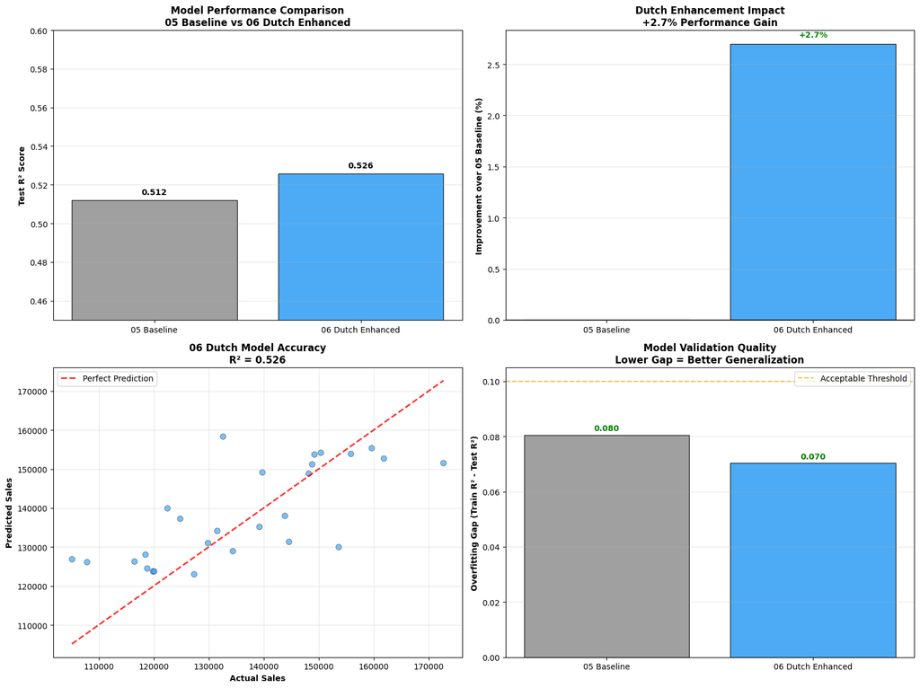

```python
# 📈 COMPREHENSIVE VISUALIZATION
# ===============================

# Create detailed visualization of results
fig, ((ax1, ax2), (ax3, ax4)) = plt.subplots(2, 2, figsize=(16, 12))

# Chart 1: Model Performance Comparison
models = ['05 Baseline', '06 Dutch Enhanced']
test_r2_values = [result_05['test_r2'], result_06['test_r2']]
colors = ['#888888', '#2196F3']

bars1 = ax1.bar(models, test_r2_values, color=colors, alpha=0.8, edgecolor='black', linewidth=1)
ax1.set_ylabel('Test R² Score', fontweight='bold')
ax1.set_title('Model Performance Comparison\n05 Baseline vs 06 Dutch Enhanced', fontweight='bold')
ax1.set_ylim(0.45, 0.60)
ax1.grid(axis='y', alpha=0.3)

# Add performance labels
for bar, value in zip(bars1, test_r2_values):
    height = bar.get_height()
    ax1.text(bar.get_x() + bar.get_width()/2., height + 0.002,
             f'{value:.3f}', ha='center', va='bottom', fontweight='bold')

# Chart 2: Improvement Analysis
improvements = [0, improvement_relative]
bars2 = ax2.bar(models, improvements, color=colors, alpha=0.8, edgecolor='black', linewidth=1)
ax2.set_ylabel('Improvement over 05 Baseline (%)', fontweight='bold')
ax2.set_title(f'Dutch Enhancement Impact\n+{improvement_relative:.1f}% Performance Gain', fontweight='bold')
ax2.axhline(y=0, color='black', linestyle='-', alpha=0.5)
ax2.grid(axis='y', alpha=0.3)

# Add improvement labels
for bar, value in zip(bars2, improvements):
    height = bar.get_height()
    if value > 0:
        ax2.text(bar.get_x() + bar.get_width()/2., height + 0.05,
                 f'+{value:.1f}%', ha='center', va='bottom', fontweight='bold', color='green')

# Chart 3: Actual vs Predicted (06 Dutch Model)
ax3.scatter(result_06['y_test_actual'], result_06['y_test_predicted'],
           alpha=0.6, color='#2196F3', s=50, edgecolor='black', linewidth=0.5)

# Perfect prediction line
min_val = min(result_06['y_test_actual'].min(), result_06['y_test_predicted'].min())
max_val = max(result_06['y_test_actual'].max(), result_06['y_test_predicted'].max())
ax3.plot([min_val, max_val], [min_val, max_val], 'r--', alpha=0.8, linewidth=2, label='Perfect Prediction')

ax3.set_xlabel('Actual Sales', fontweight='bold')
ax3.set_ylabel('Predicted Sales', fontweight='bold')
ax3.set_title(f'06 Dutch Model Accuracy\nR² = {result_06["test_r2"]:.3f}', fontweight='bold')
ax3.grid(True, alpha=0.3)
ax3.legend()

# Chart 4: Overfitting Comparison
gap_values = [result_05['overfitting_gap'], result_06['overfitting_gap']]
bars4 = ax4.bar(models, gap_values, color=colors, alpha=0.8, edgecolor='black', linewidth=1)
ax4.set_ylabel('Overfitting Gap (Train R² - Test R²)', fontweight='bold')
ax4.set_title('Model Validation Quality\nLower Gap = Better Generalization', fontweight='bold')
ax4.axhline(y=0.1, color='orange', linestyle='--', alpha=0.7, label='Acceptable Threshold')
ax4.grid(axis='y', alpha=0.3)
ax4.legend()

# Add gap labels
for bar, value in zip(bars4, gap_values):
    height = bar.get_height()
    color = 'green' if value < 0.1 else 'orange' if value < 0.15 else 'red'
    ax4.text(bar.get_x() + bar.get_width()/2., height + 0.001,
             f'{value:.3f}', ha='center', va='bottom', fontweight='bold', color=color)

plt.tight_layout()
plt.show()
```